# Har vi funnet en av dødstalismanene?

### Computational essay av Nanna Bryne

### FYS2130 Svingninger og bølger (våren 2021)

Professor i fysikk Erik Adli har instruert oss ungdommer (les: tyveåringer) om "[...] grunnleggene aspekter om mekaniske og elektriske svingninger, samt en hel del om forskjellige typer bølger." (fra emnebeskrivelsen i FYS2130) Det vi ikke visste, var at han er på hemmelig oppdrag fra Galtvort, ute etter å finne en forsvunnet dødstalisman, nemlig Harry Potters usynlighetskappe. Som lærde i magiverdenen, har vi ikke oversett den skjulte agendaen, og anser det som vår plikt overfor rektor McSnurp å gjøre alt vi kan for å skaffe en slik. Sammen med medamatørfysiker Anna Pauline Hjertvik Aasen, skal jeg forsøke å bruke det vi har lært til å sette sammen usynlighetskappen.

```python
import numpy as np
import matplotlib.pyplot as plt
```

```python
def DeathlyHallows():
    cloak = np.array([[-1,0], [1,0], [0,1.35], [-1,0]])
    wand = np.array([[0,0], [0,1.35]])
    theta = np.linspace(0, 2*np.pi, 1000)
    stonex = 0.5*np.cos(theta)
    stoney = 0.5*np.sin(theta) + 0.5
    plt.plot(cloak[:,0], cloak[:,1], lw=3, c='olive')
    plt.plot(wand[:,0], wand[:,1], ls='--', c='grey')
    plt.plot(stonex, stoney, ls='--', c='grey')
    plt.axis('equal')
    plt.title('Dødstalismanene')
    plt.show()
```

[figure not shown]

```python
DeathlyHallows()
```

# Har vi en plan?

Vi skal i utgangspunktet se på materialer som finnes. Dersom dette viser seg umulig, ser vi på hypotetiske materialer. Tanken er å tilpasse brytningen fra innkommende lys slik at det ikke reflekteres synlig lys fra mennesket inni kappen. Vi vil blant annet bruke Snells lov; $$n_i \sin(i) = n_b \sin(b),$$ der $n_i$ og $n_b$ er brytningsindeksene til henholdsvis første og andre medium, og $i$ og $b$ er vinklene. Det kan også bli aktuelt å se på impedans. Vi har i tillegg noen ideer som likner mekanismen i en ultralydundersøkelse. Den siste (og kanskje beste) ideen vi har dreier seg om å sette sammen materialer slik at lyset følger en bestemt vei gjennom kappen, altså rundt mennesket. Vi har tenkt til å anta monokromatisk lys, og variere bølgelengder (f.eks. rødt vs. blått lys).

Så, nei, vi har ikke en plan, men vi gleder oss til å se hvor ideene tar oss.

# Hvordan skal vi grave ned Harry?

Det er mange konsepter i fysikken som kan brukes til å forme et system slik vi ønsker det. Tanken er å rett og slett endre veien synlig lys går for å omgå mennesket under kappen, la oss kalle han Harry. Av fenomener og konsepter som kan endre veien til lys inngår impedans, speil (refleksjon), brytning (refraksjon), linser og generell relativitet (e.g. sorte hull). Vi blir nødt til å velge oss en tilnærming til dette problemet som ikke tar for seg altfor mange forskellige fysiske konsepter, da vi ikke har mer enn noen få uker igjen før Harry virkelig må ha kappen sin. Etter mange youtube-videoer, én-til-én-konsultasjoner og sprøe ideer, har vi kommet fram til en strategi. Vi vil endre lysets bane ved hjelp av ulike materialer med ulike brytningsindekser. Denne metoden deler vi opp i de to mulige løsninger. Til å begynne med, tar vi ikke høyde for dispersjon.

La oss holde oss i to dimensjoner. Vi ønsker å lage en kappe som leder lyset som i utgangspunktet skal reflekteres av Harrys kropp og føres inn i Voldemorts øyne, i en bane som omgår Harry og heller treffer bakgrunnen. Her er det uendelig mange ting å tenke på, så vi må forenkle situasjonen ganske kraftig. Vi har valgt å fokusere på å tvinge frem bildet av bakgrunnen, fremfor å stanse de innkommende solstrålene som skal treffe Harry og reflekteres. Her tror jeg det passer med en figur:

[figure not shown]

**FIGUR 1**: Situasjonen illustrert, med den ønskelige banen til lyset.

For enkelhets skyld, sier vi at bakgrunnen er utsyrt med linser eller speil slik at lyset som reflekteres, reflekteres vannrett inn på baksiden av kappen. Tanken er å lage en kappe som består av materialer i hvilke lyset endrer hastighet. Men hvordan må de vinkles? Og kan vi bøye lyset hvilken som helst vei? Dette skal vi undersøke ved å benytte én av de to følgende modelleringene.

## **I**: Diskret endring av brytningsindeks $n(\mathbf{r})$

Kan vi sette sammen ulike materialer med ulik brytningsindeks for å lede lyset slik vi vil? Hvor mange ville vi trengt?

[figure not shown]

**FIGUR 2**: Diskret endring av brytningsindeks.

De ulike lagene har en brytningsindeks tilpasset slik at lyset avbøyes som vist på figuren. Men er det mulig da? Og hvordan kan vi ta høyde for lys fra ulike vinkler? Det blir også nødvendig å se på hvordan materialene må vinkles for å få refraksjon. Illustrasjonen ovenfor er noe misvisende i det at lyset kommer tilsynelatende vinkelrett på det gulgrønne materialet og får en bøyning etter det, noe som strider mot Snells lov.

Kanskje må vi ha veldig mange ulike materialer i kappen. Er det enklere å lage en kontinuerlig profil? Vi tenker oss at sonene blir uendelig tynne.

## **II**: Kontinuerlig endring av brytningsindeks $n(\mathbf{r})$

[figure not shown]

**FIGUR 3**: Varm asfalt-eksempelet.

Vi ser for oss en kappe med en fasong som omgår Harry. Dette ønsker vi skal være banen til lyset. Kan vi, utfra denne, finne den nødvendige funksjonen $n(\mathbf{r})$? Hvis vi klarer det, kan vi lage flere baner slik at lys fra alle høyder omgår Harry? Eller klarer vi kanskje lede alt av lyset gjennom samme ene kappe-lag?

[figure not shown]

**FIGUR 4**: Kontinuerlig endring av brytningsindeks.

# Sannhetens øyeblikk

Det virker for oss aller tøffest å lage en kappe med et kontinuerlig brytningsfelt $n(\mathbf{r})$, så vi går for **II**.

Vi forholder oss til to dimensjoner, så $n(\mathbf{r}) = n(x,y)$. Vi lar $y = y(x)$ være en enkel kurve slik at brytningsindeksen bare endrer seg med x-aksen;

$$n(x,y) = n(x, y(x)) = n(x).$$

Kurven $y(x)$ representerer lysets bane. Denne kan være nesten hva som helst, men må være kontinuerlig og går bare enten med eller mot x-aksen.

Etter mye drodling, gjenkjenner vi kurvene vi tegner som Gauss-kurver;

$$y(x) = h_i e^{-x^2/(2\sigma_i^2)},$$

der $h_i$, $\sigma_i$ er henholdsvis høyden og "standardavviket" på kappelag $i$. Vi setter Harry i origo slik at "gjennomsnittet" $\mu=0$. Vi tror denne kurven er hensiktsmessig da den kan tilpasses enkelt, er symmetrisk og retter seg ut langs x-aksen. Iallfall for alle lysstråler som kommer vannrett inn på "banen sin", vil vi kanskje kunne slippe å måtte bøye dem drastisk ved inntrengningen.

# Fysikken

Vi skal kort gå gjennom noen fysiske konsepter som vi kommer til å bruke i modelleringen.

**Brytningsindeksen** $n$ til et stoff forteller hvor stor evne stoffet har til å lede lys. Indeksen er definert utifra det utgangspunkt at vakuum har $n=1$. Luft er såpass tynt, at brytningsindeksen til denne ofte sies å være som i vakuum, $n=1$. Sammen med Snells lov (denne skal vi komme tilbake til), betyr da dette i praksis at brytningsindeksen til et materiale inneholder informasjon hvor mye lys blir avbøyd i overgangen fra luft/vakuum til nevnt materiale, eller vice versa.

**Snells lov** beskriver en situasjon der lys beveger seg fra et medium $a$ med brytningsindeks $n_a$ til et medium $b$ med brytningsindeks $n_b$. Hvis lyset har en vinkel $\theta_a$ med normalen til grenseflaten, kan vi finne vinkelen den får i $b$, $\theta_b$, ved

$$n_a \sin{\theta_a} = n_b \sin{\theta_b}.$$

[figure not shown]

**FIGUR 5**: Snells lov.

**Fermats prinsipp** kan skrives med hensyn på brytningsindeksen $n = n(x,y,z)$ som

$$\delta P = \delta \int_{s_1}^{s_2} n \text{ d}s = 0$$

og heter seg at lyset alltid beveger seg fra $s_1$ til $s_2$ i den banen som tar kortest tid å gjennomføre. I vanlig euklidske rom der brytningsindeksen er konstant lik 1, vil dette alltid svare til en rett linje i rommet.

Vi skriver opp **Euler-Lagrange-likningen** som minimerer $P = \int F(x, y, y') \text{ d}x$ der $y=y(x)$ og $y' = \frac{\text{d}y}{\text{d}x}$;

$$\frac{\partial F }{\partial y} - \frac{\text{d}}{\text{d}x} \left( \frac{\partial F }{\partial y'}\right) = 0,$$

men går ikke noe dypere inn i dette.

**Fresnels likninger** gir oss refleksjonen $R$ av ikke-polarisert EM-bølger mot et grensesnitt med en innfallsvinkel $\theta_i$ og brytningsvinkel $\theta_t$ ved $R = \frac{1}{2} (R_s + R_p)$ der

\begin{align*} R_s &= \left( \frac{\cos \theta_i - n \cos \theta_t}{\cos \theta_i + n \cos \theta_t} \right)^2 \\ R_p &= \left( \frac{-n^2 \cos \theta_i + n \cos \theta_t}{n^2 \cos \theta_i + n \cos \theta_t} \right)^2\\ \end{align*}

og $n= n_1/n_2$ er forholdet mellom brytningsindeksene til hhv. første og andre medium.

Refleksjonen av en EM-bølge normalt på grensesnittet, kan vi finne som

$$R = \big(\frac{n_1-n_2}{n_1+n_2}\big)^2. $$

# Matematikken

Vi lar $n(x, y) = n(x, y(x)) = n(x)$ være brytningsindeksen langs en kurve $y(x)$. Vi bruker Fermats prinsipp og at $\text{d}s = \sqrt{\text{d}x^2+\text{d}y^2} =\sqrt{1+y'^2}\text{d}x $ til å finne uttrykket

$$ P = \int_{s_1}^{s_2} n(x) \sqrt{1+y'^2}\text{d}x = \int_{s_1}^{s_2} F(x, y') \text{d}x$$

.

Altså er $F = F(x, y') = n(x) \sqrt{1+y'^2}$. Innsatt i Euler-Lagrange-likningen, blir det første leddet $\frac{\partial F }{\partial y} = 0$ lik null, ettersom $F = F(x, y')$ ikke er avhengig av $y$. Da må også det andre leddet bli null,

$$\frac{\text{d}}{\text{d}x} \left( \frac{\partial F }{\partial y'}\right) = 0,$$

som impliserer at $\frac{\partial F }{\partial y'}$ må være konstant. Vi kan nå finne et utrykk for $n=n(x)$.

\begin{align} \frac{\partial F }{\partial y'} &= K \\ \frac{\partial}{\partial y'} (n \sqrt{1+y'^2}) &= K \\ \frac{n y'}{\sqrt{1+y'^2}} &= K\\ \Rightarrow n(x) &=\frac{K \sqrt{1+(y'(x))^2} }{y'(x)} \end{align}

Vi kan også forenkle konstanten $K$ ved å observere at $y'= \frac{\text{d}y}{\text{d}x} = \tan{\varphi} = \frac{\sin{\varphi}}{\cos{\varphi}}$ der $\varphi$ er vinkelen banen har med x-aksen.

\begin{align} K &= \frac{n y'}{\sqrt{1+y'^2}} \cdot \frac{\cos{\varphi}}{\cos{\varphi}} \\ \Rightarrow K &= n(x) \cdot \sin{\varphi} \end{align}

Dette betyr også at $n(x)\sin{\varphi}$ alltid er den samme langs kurven.

Så hvordan bestemmer vi $K$? Og fungerer dette med alle kurver $y(x)$? Dette håper vi å få svar på i løpet av forskningen vår.

# Magien

Vi skal gjøre en hel den antakelser for å få dette til å gå opp.

- Både Voldemort og Harry står i ro.
- Lyset reflekteres fra bakgrunnen (selv om Harry er i veien...) horisontalt mot Harry
- Vi antar sylindersymmetri om Harry, og holder oss derfor i to dimensjoner.
- Antar ikke-polarisert lys.

Vi har også antatt ingen/negisjerbar dispersjon i materialene, men dette er noe vi hadde ambisjoner om å undersøke nøyere, som vi ikke rakk.

Gjør vi alle disse antakelsene, samt legger godvilja til, kan vi konstruere en usynlighetskappe på følgende vis.

Vi tenker oss at kappen består av $N$ lag. Hvert kappelag $i$ har sin fasong $y_i(x)$ og brytningsindeksfunksjon $n_i(x)$.

[figure not shown]

**FIGUR 6**: Situasjonen illustrert med synsvinkelen til Voldemort $\theta$. Zoomer inn på de markerte områdene i figur 7 og 8 for et hvilket som helst kappelag. Merk at innerste kappelag på tegningen ikke nødvendigvis er det; tanken er at det kan være en hviken som helst $i$.

Materialene på baksiden av kappen (høyre side på figur 1/6) har vertikale grensesnitt slik at de horisontale lysstrålene ikke brytes. Materialene på forsiden av kappen (venstre side på figur 1/6) har skrå grensesnitt, en vinkel $\alpha$ fra loddrett posisjon (figur 8), tilpasset slik at lysstrålene brytes og treffer øynene til Voldemort med en vinkel $\theta$ med negativ x-akse (figur 6).

[figure not shown]

**FIGUR 7**: Grensesnittene foran på kappen. Overdrevne størrelser. Det er her initialbetingelsen som bestemmer $K$ kommer fra.

[figure not shown]

**FIGUR 8**: Grensesnittene bak på kappen. Antar at kappen strekker seg langt nok ut bak til at $\frac{\text{d}y}{\text{d}x} \simeq 0$ inni kappen og derfor ikke behøver brytning i ytterkanten. (Merk at situasjonen er lik som i figur 7 med $\alpha = 0$.) De mørkere lagene er kun en idé om hvordan materialene kan ligge inni kappen.

Når $|x| \rightarrow 0$ vil $y_i'(x)\rightarrow 0$ og dermed $n_i(x)\rightarrow \pm \infty$. Dette løser vi ved å plassere et speil der dette skjer.

# Kodingen

Vi lager først en *veldig enkel* klasse som lagrer informasjon om menneskene involvert. På den måten kan vi enkelt skille parametre fra de vi etterhvert vil endre på og de som bestemmes av systemet.

```python
class Person:

    def __init__(self, navn, hoyde, bredde, posisjon):
        self.navn = navn
        self.h, self.b, self.l = hoyde, bredde, posisjon
```

Klassen Kappe skal ta inn informasjon om kappens ønskede form og formål, simulere lysets bane $y(x)$ og kalkulere kappelagenes brytningsindeks $n(x)$. Til å begynne med bruker vi at $y(x)$ er en Gausskurve.

```python
class Kappe:

    def __init__(self, usynlig, observatør, bredde_venstre, bredde_høyre, alpha, N_lag, høyde=None, n_steg=1000):

        self.u, self.o = usynlig, observatør # instanser av klassen Person
        self.b_h, self.b_v = bredde_høyre, bredde_venstre
        self.alpha, self.N = alpha, N_lag
        self.AN = høyde or self.u.h*1.01 # maksimal høyde på kappe

        # forbereder tomme arrays:
        self.x = np.linspace(-self.b_v, self.b_h, n_steg)
        self.y = np.zeros((self.N, n_steg))
        self.yder = np.zeros((self.N, n_steg))
        self.n = np.zeros((self.N, n_steg))


    def lag_gauss(self, sigma1, sigmaN):

        # sigma1, sigmaN = første, siste std. i gausskurvene
        N = self.N
        A1, AN = self.u.h, self.AN

        dsigma = (sigmaN-sigma1)/(N-1)
        dH = A1/(N-1)
        dA = (AN - A1)/(N-1)

        for i in range(N):
            Ai = A1 + i*dA - i*dH  # -i*dH: "fjerner det vi løfter"
            self.y[i,:] = Ai * np.exp(-self.x**2 / (2*(sigma1 + i*dsigma)**2)) + i*dH  # litt ulik y for hver i
            self.yder[i,:] = np.gradient(self.y[i,:], self.x[1] - self.x[0])

        return self.x, self.y, self.yder

    def brytningsindeks(self, tol=0.01):

        # finner brytningsindeks-funksjonen til hvert lag i kappen:

        for i in range(self.N):

            theta = np.arctan2((self.o.h - self.y[i,0]), (self.o.l - self.b_v)) # se figur 6
            phi = np.arctan(self.yder[i,0])
            theta_a = self.alpha - phi
            theta_b = self.alpha + theta

            K = np.sin(phi) * np.sin(theta_b) / np.sin(theta_a)

            assert theta_b > theta_a, 'Umulig n'
            assert theta_b < np.pi/2, 'Går tilbake over grensesjikt'

            self.n[i,:] = K * np.sqrt(1 + self.yder[i,:]**2) / self.yder[i,:]
            self.n[i, np.abs(self.yder[i,:]) < tol] = float('nan') # forkaster de n som går mot uendelig

        return self.x, self.n

    def refleksjon_i_grensesnitt(self):

        self.Rf = np.zeros(self.N)
        self.Rb = np.zeros(self.N)

        print(' i =   | R =  ')
        print('-'*25)

        for i in range(self.N):
            # foran:

            theta = np.arctan2((self.o.h - self.y[i,0]), (self.o.l - self.b_v)) # se figur 6
            phi = np.arctan(self.yder[i,0])
            theta_a = self.alpha - phi
            theta_b = self.alpha + theta

            # Fresnels likninger:

            Rs = ((np.cos(theta_a) - 1/self.n[i, 0] * np.cos(theta_b)) / (np.cos(theta_a) + 1/self.n[i,0] * np.cos(theta_b)))**2
            Rp = ((- 1/self.n[i, 0]**2 * np.cos(theta_a) + 1/self.n[i, 0] * np.cos(theta_b)) / (1/self.n[i, 0]**2 * np.cos(theta_a) + 1/self.n[i,0] * np.cos(theta_b)))**2
            self.Rf[i] = 1/2 * (Rs+Rp)

            # bak:

            self.Rb[i] = ((1-self.n[i, -1]) / (1+self.n[i, -1]) )**2

            print(f'{i:5.0f}  |{self.Rf[i]*100:5.0f} % /{self.Rb[i]*100:5.0f} % ')

        print('-'*25)

        return self.Rf, self.Rb


    def sjekk_n(self):

        # sjekker at |n|>1 overalt
        if np.min(np.abs(self.n[np.isnan(self.n)==False])) < 1:
            print('Umulig n')
            print('Minste n: ', np.min(np.abs(self.n[np.isnan(self.n)==False])))
            return False
        else:
            print('Mulig n. Kjempebra jobba!')
            return True


    def plot_kappe(self, syn=False, d=0.01, xtra_x=1, speil_bredde=0.2):

        plt.figure(figsize=(12, 6))

        # uthever formen til kappen:
        kappe_x = np.array([self.b_h, self.b_h, -self.b_v, -self.b_v])
        kappe_y = np.array([-d, self.AN+d, self.AN+d, self.y[0,0]-d])
        kappe_X = np.append(kappe_x, self.x)
        kappe_Y = np.append(kappe_y, self.y[0,:]-d)
        plt.plot(kappe_X, kappe_Y, lw=3, c='k')

        # legger til det øverste speilet:
        speil_x = [-speil_bredde/2, speil_bredde/2]
        speil_y = [self.AN+d, self.AN+d]
        plt.plot(speil_x, speil_y, lw=3, c='lime')

        # plotter lysstrålenes bane, med eller uten sluttfasen:
        if syn==False:
            for j in range(self.N):
                plt.plot(self.x,self.y[j,:],lw=0.7)
        else:

            if self.y[0,0] > 0.05:
                print(f'Kappen er {self.y[0,0]*100:.0f} cm over bakken! {self.o.navn} ser føttene til {self.u.navn}.')

            # plotter personene som trekanter:
            plt.plot([self.u.l-self.u.b/2, self.u.l+self.u.b/2, self.u.l, self.u.l-self.u.b/2], [0, 0, self.u.h, 0], lw=4, c='saddlebrown')
            plt.plot([-self.o.l-self.o.b/2, -self.o.l + self.o.b/2, -self.o.l, -self.o.l-self.o.b/2],[0, 0, self.o.h, 0], lw=4, c='grey')

            for j in range(self.N):

                X = np.append(np.array([-self.o.l, -self.b_v]), self.x)
                Y = np.append(np.array([self.o.h, self.y[j,0]]), self.y[j,:])

                X = np.append(X, np.array([self.b_h, self.b_h+xtra_x]))
                Y = np.append(Y,  np.array([self.y[j,-1], self.y[j,-1]]))

                plt.plot(X, Y, lw=0.7)

        plt.grid()
        plt.title('Usynlighetskappen og lysstrålenes baner')
        plt.xlabel('x [m]')
        plt.ylabel('y [m]')

    def plot_n(self, n_ylim=None):

        n0 = np.abs(self.n[0, 0])
        if np.isnan(n0):
            n_ylim = 5 or n_ylim

        else:
            n_ylim = n0*1.1 or n_ylim

        plt.figure(figsize=(12,6))
        Alpha = self.alpha*180/np.pi # rad -> grader
        plt.suptitle(r'$n(x)$ når $\alpha$ = %.0f grader' %Alpha)

        plt.subplot(121)
        for j in range(self.N):
            plt.plot(self.x, self.n[j,:], lw=0.7)

        plt.axhline(1, ls='--', c='firebrick')
        plt.axhline(-1, ls='--', c='firebrick')
        plt.grid()
        plt.xlabel('x [m]')
        plt.ylabel('n')

        plt.subplot(122) # zoomet plott
        for j in range(self.N):
            plt.plot(self.x, self.n[j,:],lw=0.7)

        plt.axhline(1, ls='--', c='firebrick')
        plt.axhline(-1, ls='--', c='firebrick')
        plt.axis([-self.b_v, self.b_h, -n_ylim, n_ylim])
        plt.grid()
        plt.xlabel('x [m]')
        plt.ylabel('n')


    def endre_alpha(self, ny_alpha):
        # endrer tilt-vinkelen alpha
        self.alpha = ny_alpha
```

Vi lager et system av noen valgte parametre og kjører koden.

```python
H = Person('Harry', 1.5, 1, 0)
V = Person('Voldemort', 1.7, 0.5, 10)
```

```python
kappe = Kappe(H, V, bredde_venstre=3, bredde_høyre=4, alpha=0, N_lag=50)
```

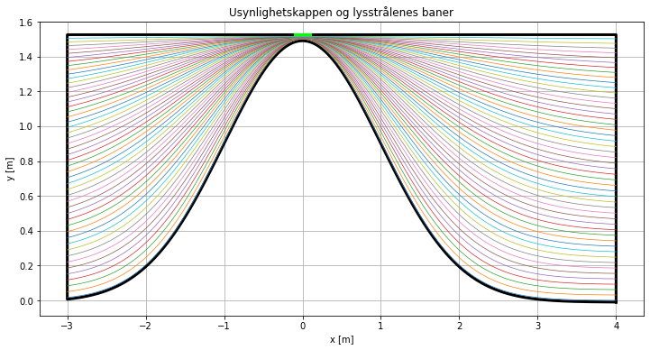

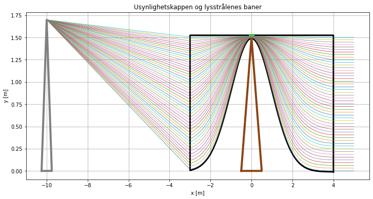

```python
kappe.lag_gauss(sigma1=1, sigmaN=2)
kappe.plot_kappe()
plt.show()
kappe.plot_kappe(syn=True)
plt.show()
```

Dette ser bra ut. La oss se på brytningsindeksen.

```
Umulig n
Minste n:  0.3474410586114922
```

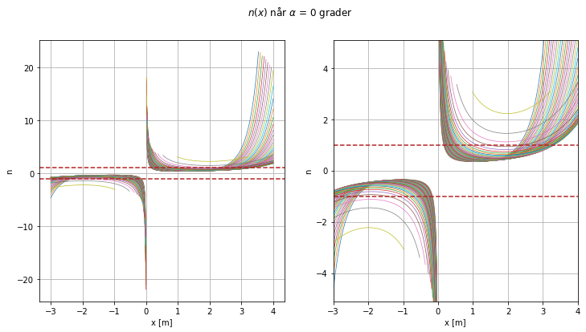

```python
kappe.brytningsindeks()
kappe.plot_n()
kappe.sjekk_n()
plt.show()
```

Brytningsindeks under 1 impliserer et stoff som er tynnere enn vakuum. Dette er ikke mulig på Galtvort engang, så her må vi forandre på ting. Vi tilter nå grensesnittene foran med en vinkel $\alpha$.

```python
alphas = np.pi * np.array([0, 1/24, 1/12, 1/8, 1/6, 1/5, 1/4, 1/3])
for alpha in alphas:
    kappe.endre_alpha(alpha)
    kappe.brytningsindeks()
    kappe.sjekk_n()
```

```
Umulig n
Minste n:  0.3474410586114922
Umulig n
Minste n:  0.3341435921718943
Umulig n
Minste n:  0.1704297153694728
Umulig n
Minste n:  0.1312151508360577
Umulig n
Minste n:  0.11316095884771897
Umulig n
Minste n:  0.10427753871177001
Umulig n
Minste n:  0.09524248737811625
Umulig n
Minste n:  0.08551811803875115
```

Da ser det ut til å være store problemer her. Vi forsøker å endre litt på kappen for å få litt snillere vinkler. Vi tar også litt færre lag, så det er lettere å se grafene.

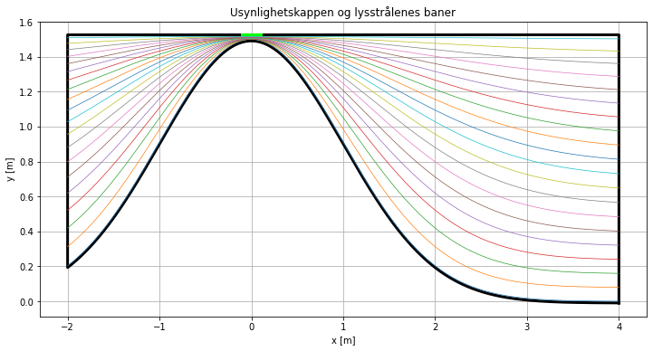

```
Kappen er 20 cm over bakken! Voldemort ser føttene til Harry.
```

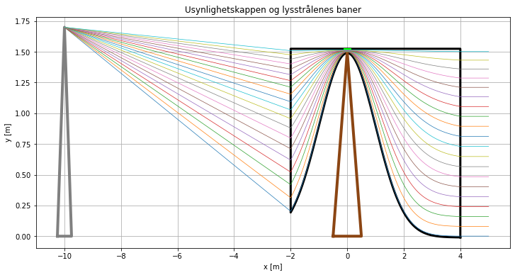

```python
kappe = Kappe(H, V, bredde_venstre=2, bredde_høyre=4, alpha=0, N_lag=20) # endret bredde_venstre

kappe.lag_gauss(sigma1=1, sigmaN=2)
kappe.plot_kappe()
plt.show()
kappe.plot_kappe(syn=True)
plt.show()
```

Vi observerer utfordringen med føttene, men først ser vi på hvordan brytningsindeksen er.

```python
alphas = np.pi * np.array([0, 1/24, 1/12, 1/8, 1/6, 1/5, 1/4, 1/3])
for alpha in alphas:
    kappe.endre_alpha(alpha)
    kappe.brytningsindeks()
    kappe.sjekk_n()
```

```
Umulig n
Minste n:  0.2608767959924858
Umulig n
Minste n:  0.6875713877943976
Mulig n. Kjempebra jobba!
Mulig n. Kjempebra jobba!
Mulig n. Kjempebra jobba!
Mulig n. Kjempebra jobba!
Mulig n. Kjempebra jobba!
Umulig n
Minste n:  0.8633497499400753
```

Her er det mange muligheter. Vi velger oss en fin $\alpha$ og jobber videre med dette systemet.

```
Mulig n. Kjempebra jobba!
```

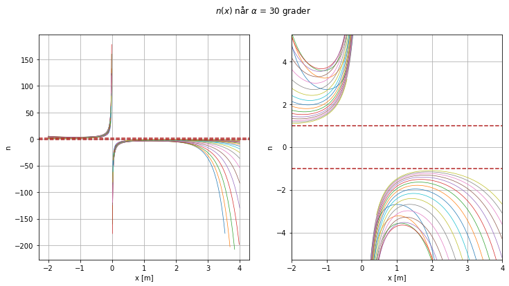

```python
kappe.endre_alpha(np.pi/6)

kappe.brytningsindeks()
kappe.plot_n()
kappe.sjekk_n()
plt.show()
```

Da var det problemet løst! Men gir plottene noen fysisk mening? Problemet rundt $x = 0$ løser vi som sagt med speil. At brytningsindeksen er positiv foran Harry har å gjøre med hvordan vi tiltet grensesnittene som bestemte initialbetingelsen til $n(x)$. Bak Harry er brytningsindeksen negativ. Dette tror vi speilet løser for oss ved å endre retningen på lyset, og siden innfallsvinkel er lik utfallsvinkel vi vi ha en symmetri om y-aksen. Altså er brytningsindeksen positiv i hele kappen.

Før vi går videre og skjuler Harrys føtter så godt vi kan, tar vi en titt på refleksjonen i grensesnittene

```python
kappe.refleksjon_i_grensesnitt()
plt.show()
```

```
 i =   | R =
-------------------------
    0  |   43 % /  nan %
    1  |   46 % /  nan %
    2  |   47 % /  nan %
    3  |   45 % /  nan %
    4  |   42 % /  103 %
    5  |   38 % /  105 %
    6  |   32 % /  108 %
    7  |   27 % /  112 %
    8  |   22 % /  117 %
    9  |   17 % /  124 %
   10  |   13 % /  135 %
   11  |   10 % /  148 %
   12  |    7 % /  165 %
   13  |    5 % /  188 %
   14  |    3 % /  218 %
   15  |    2 % /  258 %
   16  |    1 % /  311 %
   17  |    1 % /  382 %
   18  |    0 % /  480 %
   19  |  nan % /  nan %
-------------------------
```

Au da! Lyset fra bakgrunnen reflekteres helt enormt mye. Det ser ikke ut til å være et like stort problem på venstre side av kappen.

# Vi gir opp

Her blir vi nødt til å gi oss mens leken er god. Vi innser at vi har tatt oss vann over hodet og lar være å finne nye, uforklarlige resultater. Likevel har vi flere forslag til hvordan man kunne gjort ting annerledes. Noen av dem handler om å:

- Prøve andre kurver, være seg sinus-kurve, parabel mm. og se hvordan brytningsindeksen oppfører seg. Deretter lage en sammensetning av fornuftige kurver (for eksempel sinus for $x<0$ og gauss for $x>0$) som vi syr sammen.
- Styre lyset mot Voldemort annerledes slik at det i bakgrunnen ikke mister størrelsen og formen sin.
- Fikse grensesnittene på baksiden med samme tankegang som på framsiden, slik at vi ikke behøver den enorme brytningsindeksen på enden. Da løses kanskje problemet med refleksjonen også. Merk at vi her måtte delt opp funksjonen vår i to uttrykk (men naturligvis fortsatt kontinuerlig).

# Harry er død

For det første er antakelsen om at lyset bare kommer horisontalt bakfra helt bak mål. Selv med ville antakelser, får vi altså ikke til å sende lyset gjennom kappen slik vi ønsker det; det er altfor stor refleksjon. Men vi har lært veldig mye av dette prosjektet og anser det ikke som noe nederlag å måtte gi oss her! Litt leit at det er ille ute med Harry da.

Alle vet rett og slett hvor Harry er gravd ned. Alle vet at Harry er død.

# Referanser

- Lecture notes og oppgaver i FYS3140
- https://en.wikipedia.org/wiki/Fermat%27s_principle
- https://en.wikipedia.org/wiki/Euler%E2%80%93Lagrange_equation
- Forelesning i FYS2130